# Drivers of Virality: Analysis of the Netflix Daily Top 10 in the US

Team: Daryna Antoniuk, Maryna Ohinska, Nazar Mykhailyshchuk

2025-12-08

# Drivers of Virality: A Statistical Analysis of the Netflix Daily Top 10 in US

**Subtitle: An Investigation into How Content Type, Exclusivity, and Seasonality Impact Viewership and Ranking Longevity.**

**Team:** Daryna Antoniuk, Maryna Ohinska, Nazar Mykhailyshchuk

**Data sources:**

- https://www.kaggle.com/datasets/prasertk/netflix-daily-top-10-in-us
- https://datasets.imdbws.com/
- we merged these datasets into a new one which we used for our research

**Research Aim**

This project aims to statistically analyze the factors that contribute to a title’s popularity on Netflix. We use the Netflix Daily Top 10 in US dataset to model and test what drives high viewership and sustained presence in the Top 10.

**Dataset Description**

The primary dataset is a daily log of the Top 10 most popular titles on Netflix, containing 7,100 observations from April 2020 to March 2022.

- Netflix Data: Includes variables such as Rank, Viewership Score, Days in Top 10, Netflix Exclusive status, and Type (Movie/TV Show).
- IMDb Enrichment: To analyze the impact of content quality, we merged the Netflix data with IMDb datasets based on title. We successfully matched a subset of titles to retrieve IMDb Rating and Genre.

## Data preparation

Before conducting any analysis, we performed a cleaned and prepared our data to ensure accuracy, consistency, and reliability of the results. First, we standardized all date fields and extracted features such as month and season, which enabled us to analyze seasonal effects in the viewership. We normalized categorical variables. For example, we replaced missing or empty values in the Netflix Exclusive column with “No”, and trimmed whitespaces to avoid duplicated categories and incorrect groupings. We also ensured that numeric fields (for example, Rank, Days in Top 10, ratings, votes) were correctly parsed as numeric types, which allows us to perform valid computation and modeling. Finally, we removed duplicates, checked for missing values, and created additional derived features (such as month number and season). As the result,we got a clean and consistent dataset suitable for reliable modeling and interpretation.

```r
library(dplyr)
library(readr)
library(ggplot2)
library(lubridate)
library(moments)

netflix_data <- read_csv("netflix_with_imdb.csv")
netflix_data <- netflix_data %>%
  mutate(
    Date_clean = as.Date(`As of`),
    Month_num = month(Date_clean),
    Season = case_when(
      Month_num %in% c(12, 1, 2) ~ "Winter",
      Month_num %in% c(3, 4, 5) ~ "Spring",
      Month_num %in% c(6, 7, 8) ~ "Summer",
      TRUE ~ "Fall"
    ),
    `Netflix Exclusive` = ifelse(is.na(`Netflix Exclusive`) | `Netflix Exclusive` == "", "No", `Netflix Exclusive`),
    `Netflix Exclusive` = trimws(`Netflix Exclusive`)
  )
```

## Descriptive Analysis

Before conducting formal hypothesis tests, we first performed an Exploratory Data Analysis (EDA) to examine the statistical properties and distributional behavior of the main outcome variable, Viewership Score.

First of all, we analyze the statistical properties of our main variable: `Viewership Score`.

```r
desc_stats <- netflix_data %>%
  summarise(
    Mean = mean(`Viewership Score`, na.rm = TRUE),
    Median = median(`Viewership Score`, na.rm = TRUE),
    SD = sd(`Viewership Score`, na.rm = TRUE),
    Min = min(`Viewership Score`, na.rm = TRUE),
    Max = max(`Viewership Score`, na.rm = TRUE),
    Skewness = skewness(`Viewership Score`, na.rm = TRUE),
    Kurtosis = kurtosis(`Viewership Score`, na.rm = TRUE)
  )

knitr::kable(desc_stats, caption = "Descriptive Statistics for Viewership Score")
```

Descriptive Statistics for Viewership Score

| Mean | Median | SD | Min | Max | Skewness | Kurtosis |
| --- | --- | --- | --- | --- | --- | --- |
| 122.7901 | 50 | 213.8616 | 1 | 1474 | 3.792755 | 19.43499 |

### Visualizing the Distribution

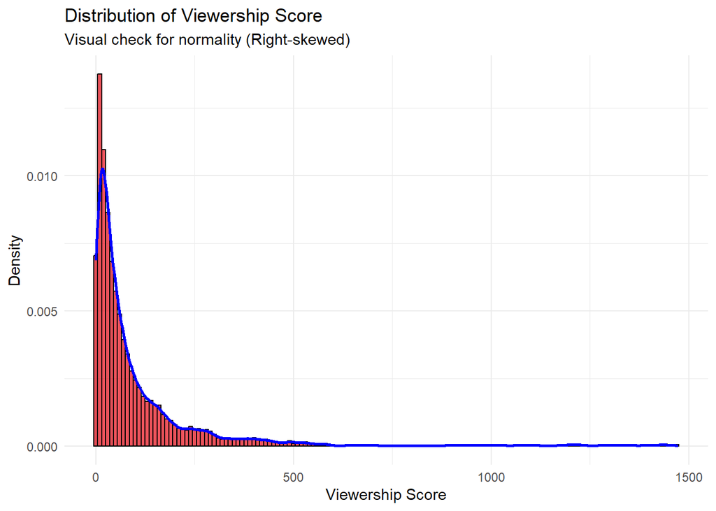

Distribution of Viewership Score

```r
ggplot(netflix_data, aes(x = `Viewership Score`)) +
  geom_histogram(aes(y = ..density..), binwidth = 10, fill = "#E50914", alpha = 0.7, color = "black") +
  geom_density(color = "blue", size = 1) +
  labs(title = "Distribution of Viewership Score",
       subtitle = "Visual check for normality (Right-skewed)",
       x = "Viewership Score", y = "Density") +
  theme_minimal()
```

As it is seen above, we computed standard descriptive statistics: mean, median, standard deviation, skewness, and kurtosis. They revealed a highly right-skewed distribution with heavy tails. The histogram visually confirmed that most titles accumulate relatively low or moderate viewership, while a small number of extremely popular titles act as outliers. The high positive skewness (3.8) and high kurtosis (19.4) support this visual assessment. This justifies our use of non-parametric tests later.

### Normality Check

```r
set.seed(123)
shapiro.test(sample(netflix_data$`Viewership Score`, 5000))
```

```
##
##  Shapiro-Wilk normality test
##
## data:  sample(netflix_data$`Viewership Score`, 5000)
## W = 0.53723, p-value < 2.2e-16
```

To formally check the normality assumption, we applied the Shapiro–Wilk test on a large random sample of the data. The resulting p-value rejects normality. Because the distribution fails both visual and statistical normality criteria, and because of the extreme outliers, we concluded that parametric tests relying on normality would not be appropriate. Therefore, based on the patterns uncovered during EDA, we adjusted our analysis plan and used non-parametric methods for subsequent hypothesis testing.

## Hypotheses testing

### Hypothesis 1: Impact of Exclusivity

$$H_0: \mu_{\text{exclusive}} =
\mu_{\text{non-exclusive}}$$
$$H_1:
\mu_{\text{exclusive}} > \mu_{\text{non-exclusive}}$$

Variables used:

- Netflix Exclusive (Yes/No)
- Viewership Score
- Days In Top 10

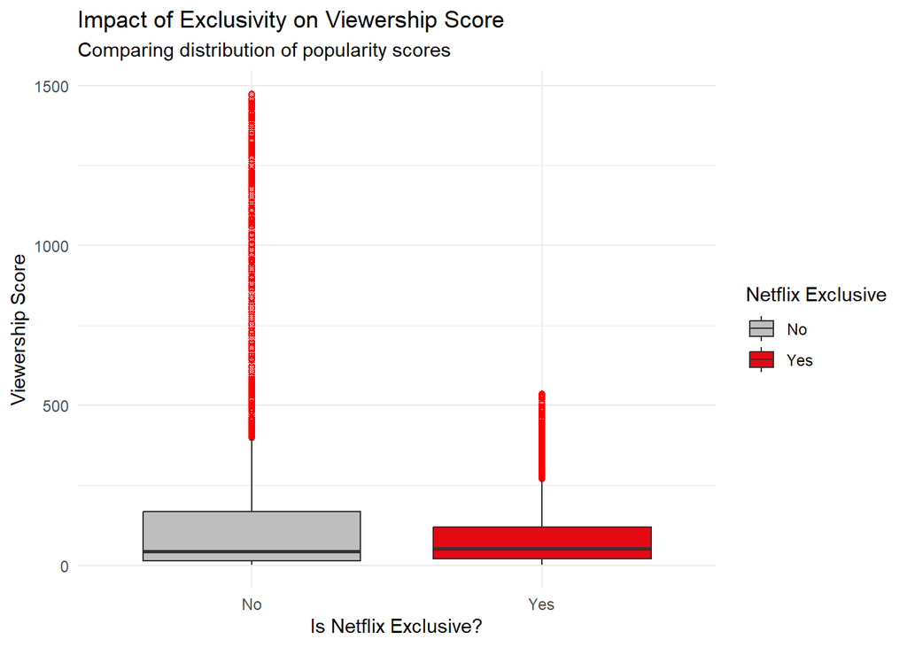

```r
ggplot(netflix_data, aes(x = `Netflix Exclusive`, y = `Viewership Score`, fill = `Netflix Exclusive`)) +
  geom_boxplot(outlier.colour = "red", outlier.shape = 1) +
  labs(title = "Impact of Exclusivity on Viewership Score",
       subtitle = "Comparing distribution of popularity scores",
       y = "Viewership Score", x = "Is Netflix Exclusive?") +
  theme_minimal() +
  scale_fill_manual(values = c("No" = "gray", "Yes" = "#E50914"))
```

**Selected Test:** Wilcoxon Rank Sum Test (Mann-Whitney U Test)

- **Justification:** While a two-sample t-test was initially considered, the visual inspection of the `Viewership Score` variable (Figure 1) revealed a heavily right-skewed distribution with significant outliers. The Shapiro-Wilk test confirms that the data does not follow a normal distribution.
- **Reasoning:** The standard t-test is sensitive to outliers and relies on the assumption of normality. Therefore, we opted for the non-parametric **Wilcoxon Rank Sum Test**. Unlike the t-test, this method compares ranks (medians) rather than means, making it robust against skewed data and outliers typical of “viral” content.

### Wilcoxon Rank Sum Test

The **Wilcoxon Rank Sum Test** (Mann–Whitney U) compares two independent groups **without assuming normality** by examining ranks instead of means.

#### Idea

The test checks whether values in one group tend to be larger than in the other based on **ranked data**.

#### Procedure

1. Combine observations from both groups.
2. Rank all values from smallest to largest (ties → average rank).
3. Compute the rank sum for one group, e.g. $R_1$.
4. Calculate the statistic
   $$U_1 = n_1 n_2 + \frac{n_1(n_1 + 1)}{2} - R_1$$
   where $n_1, n_2$ are sample sizes.
5. Take the smaller of $U_1$ and $U_2$ to compute the p-value.

#### What it tests

- $H_0: P(X > Y) = 0.5$
- $H_1: P(X > Y) > 0.5$

$X$ and $Y$ represent values from the two groups being compared (e.g., exclusive vs. non-exclusive). $P(X \> Y)$ is the probability that a randomly chosen value from group $X$ is larger than one from group $Y$.

If the exclusive group consistently gets higher ranks, $H_0$ is rejected

### Running Test

```r
test_h1 <- wilcox.test(`Viewership Score` ~ `Netflix Exclusive`,
                       data = netflix_data,
                       alternative = "greater") # check if Yes > No

print(test_h1)
```

```
##
##  Wilcoxon rank sum test with continuity correction
##
## data:  Viewership Score by Netflix Exclusive
## W = 5638019, p-value = 0.9147
## alternative hypothesis: true location shift is greater than 0
```

```r
netflix_data %>%
  group_by(`Netflix Exclusive`) %>%
  summarise(Median_Score = median(`Viewership Score`), Count = n())
```

```
## # A tibble: 2 × 3
##   `Netflix Exclusive` Median_Score Count
##   <chr>                      <dbl> <int>
## 1 No                            44  2501
## 2 Yes                           53  4599
```

### Conclusion

The Wilcoxon Rank Sum Test was conducted to test whether Netflix Exclusive titles achieve higher viewership scores than non-exclusive titles.

Therefore, we fail to reject the null hypothesis: being a *Netflix Exclusive* does not have a statistically significant effect on viewership scores in the Daily Top 10. The observed difference in medians is likely due to random variation rather than a real underlying effect.

### Hypothesis 2: Seasonality and Content Type

$H_0$: Type and Season are independent

$H_1$: Type and Season are dependent

Variables:

- As of (converted to season)
- Type

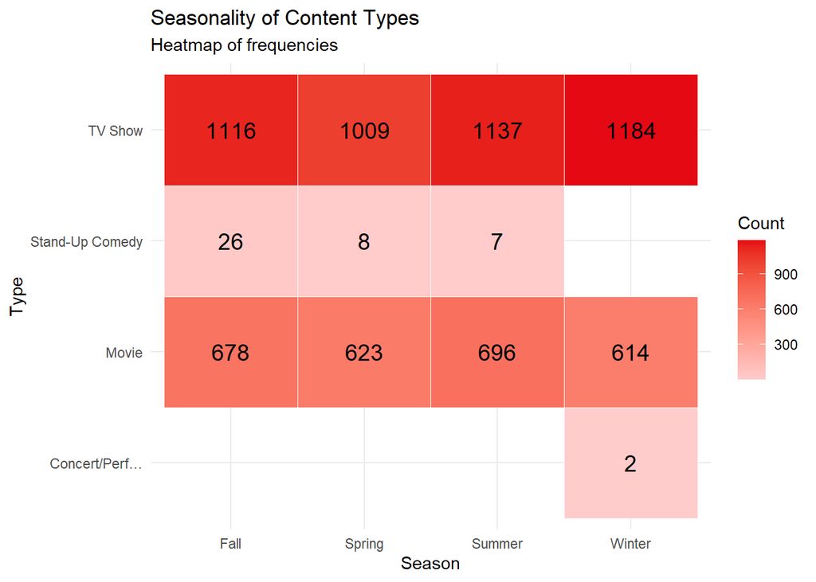

```r
heatmap_viz <- netflix_data %>%
  count(Season, Type)

ggplot(heatmap_viz, aes(x = Season, y = Type, fill = n)) +
  geom_tile(color = "white") +
  geom_text(aes(label = n), size = 5) +
  scale_fill_gradient(low = "#ffcccc", high = "#E50914") +
  labs(title = "Seasonality of Content Types",
       subtitle = "Heatmap of frequencies",
       fill = "Count") +
  theme_minimal()
```

**Selected Test:** Pearson’s Chi-Squared Test of Independence (with filtering)

- **Justification:** The Chi-squared test requires that the expected frequency in each cell of the contingency table is at least 5. Our preliminary heatmap analysis (Figure 2) indicated that specific content categories, such as “Stand-Up Comedy” and “Concert/Performance,” had extremely low counts across seasons (often <5).
- **Data Adjustment:** Inclusion of these sparse categories would violate test assumptions and yield unreliable p-values. Consequently, we filtered the dataset to include only the two dominant categories: **“TV Show”** and **“Movie”**, ensuring sufficient sample size for a valid Chi-square analysis.

### Pearson’s Chi-Squared Test of Independence

The **Chi-Squared Test** checks whether two categorical variables are **independent** by comparing observed counts to expected counts under independence.

#### Idea

If the variables are independent, the **observed frequency** in each category should be close to the **expected frequency** calculated from the marginal totals.

#### Procedure

1. Construct a **contingency table** of counts for the two categorical variables.
2. Compute **expected counts** for each cell assuming independence:
   $$E_{ij} = \frac{(\text{row total})_i \times (\text{column
   total})_j}{\text{grand total}}$$
3. Calculate the Chi-squared statistic:
   $$\chi^2 = \sum_{i,j} \frac{(O_{ij} - E_{ij})^2}{E_{ij}}$$
   where $O_{ij}$ is the observed count and $E_{ij}$ is the expected count.
4. Determine **degrees of freedom**:
   $$df = (\text{number of rows} - 1) \times (\text{number of columns} - 1)$$
5. Compare the computed $\chi^2$ to the **Chi-squared distribution** with $df$ degrees of freedom to get the p-value.

#### Interpretation

- **p-value < α** → reject $H_0$, variables are likely **dependent**.
- **p-value ≥ α** → fail to reject $H_0$, no evidence of dependence.

### Running Test

```r
chisq_data <- netflix_data %>%
  filter(Type %in% c("TV Show", "Movie")) %>%
  filter(!is.na(Season))

season_table <- table(chisq_data$Type, chisq_data$Season)

test_h2 <- chisq.test(season_table)
print(test_h2)
```

```
##
##  Pearson's Chi-squared test
##
## data:  season_table
## X-squared = 8.4588, df = 3, p-value = 0.03742
```

```r
print(season_table)
```

```
##
##           Fall Spring Summer Winter
##   Movie    678    623    696    614
##   TV Show 1116   1009   1137   1184
```

### Conclusion

Pearson’s Chi-squared test of independence was used to examine whether the season of the year is associated with the type of content (Movie vs. TV Show) appearing in the Daily Top 10.

The test produced a Chi-squared statistic of $\;8.46\;$ and a p-value of $\;0.0374\;$. Since the p-value is below the significance level of $0.05$, we reject the null hypothesis of independence.

Thus, there is a statistically significant relationship between seasonality and content type. The distribution of movies versus TV shows varies across seasons rather than remaining constant. For example, the data indicates a stronger presence of TV shows during the Winter season compared to other periods.

### Hypothesis 3: Content Quality vs. Popularity (IMDb Ratings)

Let $\mu_R$ denote the mean IMDb rating of Top-10 titles. We consider titles with IMDb rating $\ge 8$ as high-quality.

$H_0: \mu_R \ge 8$

$H_1: \mu_R < 8$

Variables:

- IMDb Rating
- Top-10 membership

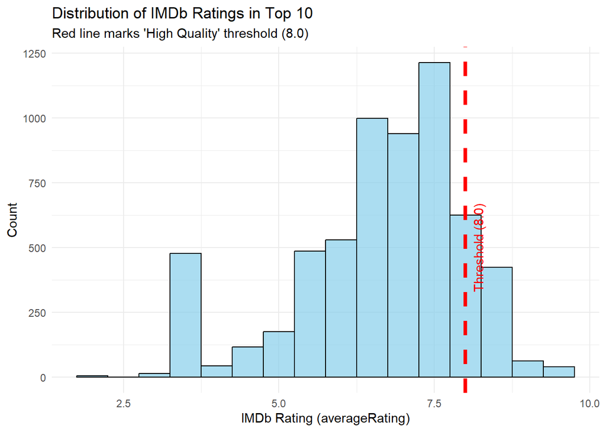

```r
imdb_viz <- netflix_data %>% filter(!is.na(averageRating))

ggplot(imdb_viz, aes(x = averageRating)) +
  geom_histogram(binwidth = 0.5, fill = "skyblue", color = "black", alpha = 0.7) +
  geom_vline(aes(xintercept = 8.0), color = "red", linetype = "dashed", size = 1.5) +
  annotate("text", x = 8.2, y = 500, label = "Threshold (8.0)", color = "red", angle = 90) +
  labs(title = "Distribution of IMDb Ratings in Top 10",
       subtitle = "Red line marks 'High Quality' threshold (8.0)",
       x = "IMDb Rating (averageRating)", y = "Count") +
  theme_minimal()
```

Assessing the normality of the averageRating variable. The code generates a Q-Q plot for visual confirmation and runs the Kolmogorov-Smirnov test as a formal statistical check, given the large sample size.

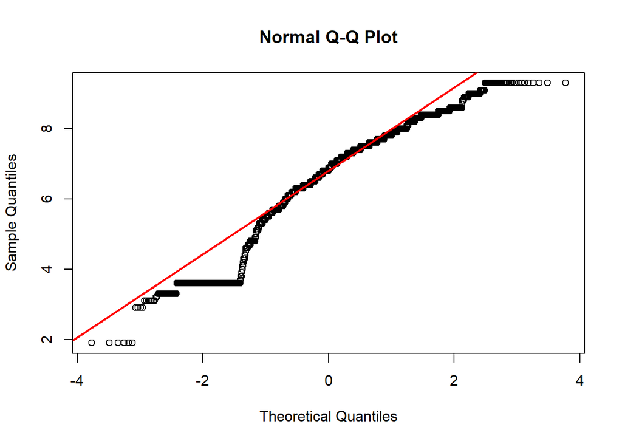

```r
qqnorm(imdb_viz$averageRating)
qqline(imdb_viz$averageRating, col = "red", lwd = 2)
```

```r
ks.test(imdb_viz$averageRating, "pnorm", mean=mean(imdb_viz$averageRating), sd=sd(imdb_viz$averageRating))
```

```
##
##  Asymptotic one-sample Kolmogorov-Smirnov test
##
## data:  imdb_viz$averageRating
## D = 0.099918, p-value < 2.2e-16
## alternative hypothesis: two-sided
```

**Selected Test:** Wilcoxon Signed Rank Test (explained procedure while testing first hypothesis)

Since the Kolmogorov-Smirnov test indicated that the IMDb ratings are not normally distributed, we proceed with the **Wilcoxon Signed Rank Test**. This non-parametric alternative to the t-test is robust to non-normality. We test the one-sided alternative hypothesis ($H_1 :\mu <8$) to determine if the true location of the ratings distribution is statistically significantly lower than the ‘high quality’ threshold of $8.0$.

### Running Test

```r
wilcox_result <- wilcox.test(imdb_viz$averageRating, mu = 8, alternative = "less")

print(wilcox_result)
```

```
##
##  Wilcoxon signed rank test with continuity correction
##
## data:  imdb_viz$averageRating
## V = 763807, p-value < 2.2e-16
## alternative hypothesis: true location is less than 8
```

```r
cat("Actual Mean Rating:", mean(imdb_viz$averageRating))
```

```
## Actual Mean Rating: 6.63775
```

Based on the Wilcoxon signed rank test ($p<2.2e−16$), we reject the null hypothesis. There is statistically significant evidence that the IMDb ratings for Netflix Top-10 titles are lower than the ‘High Quality’ threshold of 8.0. The actual mean rating of $6.64$ further confirms that the typical content in the Top 10 falls well below this standard.

## Linear Regression

To examine whether higher-quality titles (measured by IMDb average rating) are associated with higher popularity, we conducted a simple linear regression with Viewership Score as the dependent variable. This model tests whether there is a significant linear trend between rating and viewership. The resulting regression model gives us very low R-squared value which indicates that ratings explain only a small fraction of the variation in popularity.

$$Viewership Score = \beta_0 + \beta_1
\times averageRating + \epsilon$$

```r
regression_data <- netflix_data %>% filter(!is.na(averageRating))

lm_model <- lm(`Viewership Score` ~ averageRating, data = regression_data)

summary(lm_model)
```

```
##
## Call:
## lm(formula = `Viewership Score` ~ averageRating, data = regression_data)
##
## Residuals:
##     Min      1Q  Median      3Q     Max
## -398.32 -118.92  -54.27   44.81 1167.85
##
## Coefficients:
##               Estimate Std. Error t value Pr(>|t|)
## (Intercept)    514.031     13.662   37.63   <2e-16 ***
## averageRating  -57.744      2.017  -28.62   <2e-16 ***
## ---
## Signif. codes:  0 '***' 0.001 '**' 0.01 '*' 0.05 '.' 0.1 ' ' 1
##
## Residual standard error: 212.4 on 6149 degrees of freedom
## Multiple R-squared:  0.1176, Adjusted R-squared:  0.1174
## F-statistic: 819.3 on 1 and 6149 DF,  p-value: < 2.2e-16
```

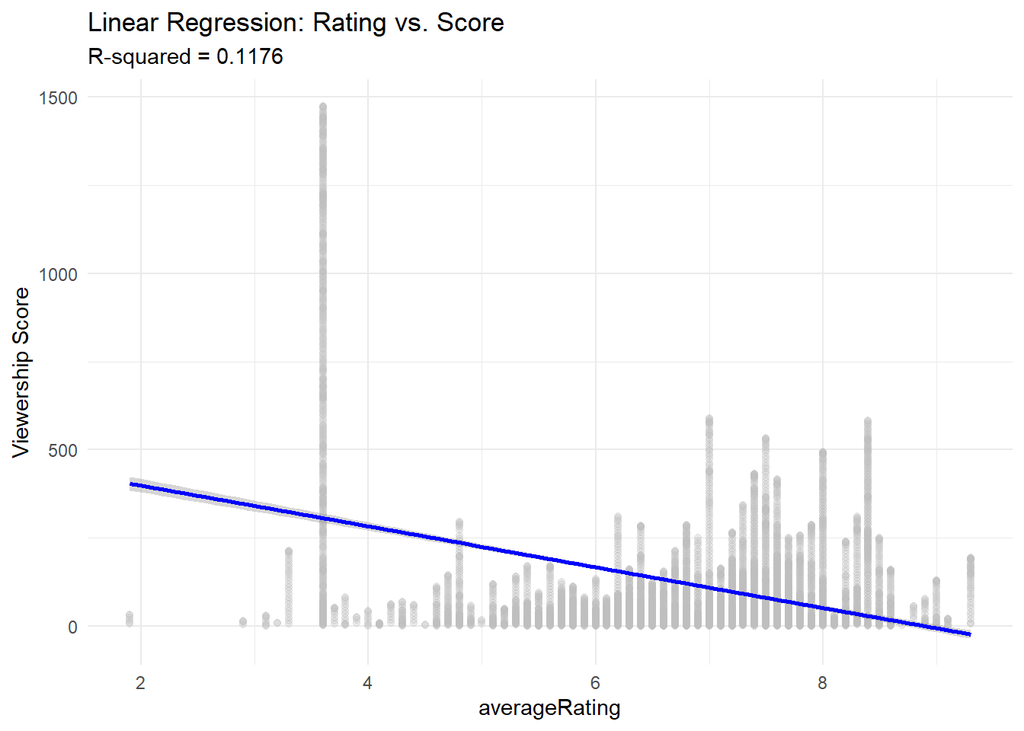

```r
ggplot(netflix_data, aes(x = averageRating, y = `Viewership Score`)) +
  geom_point(alpha = 0.3, color = "gray") +
  geom_smooth(method = "lm", color = "blue") +
  labs(title = "Linear Regression: Rating vs. Score",
       subtitle = paste("R-squared =", round(summary(lm_model)$r.squared, 4))) +
  theme_minimal()
```

To deal with this problem we introduced a dummy variable identifying the outlier and incorporated it into the regression model. This adjustment dramatically improved the model’s ability to explain data, increasing the R-squared to 0.514. Importantly, once this anomaly is accounted for, the relationship between IMDb rating and viewership becomes positive and statistically significant.

```r
regression_data <- netflix_data %>%
  filter(!is.na(averageRating)) %>%
  mutate(
    is_viral_outlier = ifelse(averageRating == 3.6, 1, 0)
  )


# Score = Beta0 + Beta1 * Rating + Beta2 * is_viral_outlier
lm_model_dummy <- lm(`Viewership Score` ~ averageRating + is_viral_outlier, data = regression_data)

summary(lm_model_dummy)
```

```
##
## Call:
## lm(formula = `Viewership Score` ~ averageRating + is_viral_outlier,
##     data = regression_data)
##
## Residuals:
##     Min      1Q  Median      3Q     Max
## -702.46  -65.81  -27.94   35.38  769.54
##
## Coefficients:
##                  Estimate Std. Error t value Pr(>|t|)
## (Intercept)      -106.287     13.395  -7.935 2.48e-15 ***
## averageRating      28.042      1.925  14.565  < 2e-16 ***
## is_viral_outlier  709.798     10.018  70.852  < 2e-16 ***
## ---
## Signif. codes:  0 '***' 0.001 '**' 0.01 '*' 0.05 '.' 0.1 ' ' 1
##
## Residual standard error: 157.6 on 6148 degrees of freedom
## Multiple R-squared:  0.5142, Adjusted R-squared:  0.5141
## F-statistic:  3254 on 2 and 6148 DF,  p-value: < 2.2e-16
```

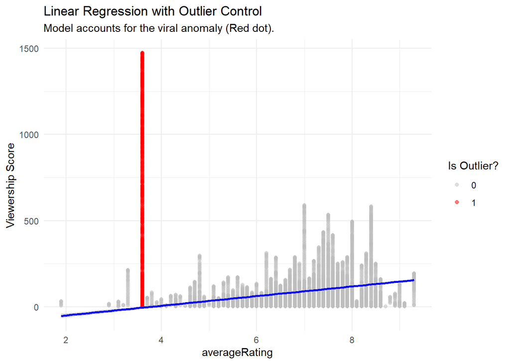

```r
ggplot(regression_data, aes(x = averageRating, y = `Viewership Score`)) +
  geom_point(aes(color = factor(is_viral_outlier)), alpha = 0.5) +

  geom_smooth(data = subset(regression_data, is_viral_outlier == 0),
              method = "lm", color = "blue") +

  labs(title = "Linear Regression with Outlier Control",
       subtitle = paste("Model accounts for the viral anomaly (Red dot)."),
       color = "Is Outlier?") +
  theme_minimal() +
  scale_color_manual(values = c("gray", "red"))
```

The results reveal two key findings:

- The ‘Viral’ Effect: The outlier variable is highly significant ($p<2e −16$) independent of the title’s rating.
- The True Relationship: Crucially, after controlling for this outlier, a statistically significant positive relationship emerges between quality and popularity. The coefficient for averageRating ($28.04$) indicates that for typical Netflix content, a 1-point increase in IMDb rating corresponds to an increase of approximately 28 viewership points. This contradicts the initial analysis, showing that quality does drive popularity when anomalies are accounted for.

## Logit Model

To evaluate whether content characteristics help predict exclusivity status, we implemented a Logistic Regression (Logit Model) using IMDb rating and viewership score as predictors. After splitting the dataset into training (80%) and testing (20%) subsets, the model identified both predictors as statistically significant. The results show that higher-rated titles are more likely to be Netflix Exclusives, while highly viewed titles are less likely to be exclusive, suggesting that exclusives tend to be more curated but not necessarily the highest-traffic releases. When evaluated on the test set, the classifier achieved an accuracy of approximately 0.668, indicating moderate predictive performance. Overall, the logit model provides evidence that content quality influences exclusivity decisions, whereas extremely popular titles tend not to be platform-exclusive.

We split the data into training (80%) and testing (20%) sets to evaluate the model’s performance.

```r
logit_data <- netflix_data %>%
  filter(!is.na(averageRating)) %>%
  mutate(Exclusive_Binary = ifelse(`Netflix Exclusive` == "Yes", 1, 0))

set.seed(123)
sample_index <- sample(seq_len(nrow(logit_data)), size = 0.8 * nrow(logit_data))
train_set <- logit_data[sample_index, ]
test_set  <- logit_data[-sample_index, ]

logit_model <- glm(Exclusive_Binary ~ `Viewership Score` + averageRating,
                   data = train_set,
                   family = binomial)

summary(logit_model)
```

```
##
## Call:
## glm(formula = Exclusive_Binary ~ `Viewership Score` + averageRating,
##     family = binomial, data = train_set)
##
## Coefficients:
##                     Estimate Std. Error z value Pr(>|z|)
## (Intercept)        -0.858707   0.168339  -5.101 3.38e-07 ***
## `Viewership Score` -0.002131   0.000190 -11.213  < 2e-16 ***
## averageRating       0.252770   0.024343  10.384  < 2e-16 ***
## ---
## Signif. codes:  0 '***' 0.001 '**' 0.01 '*' 0.05 '.' 0.1 ' ' 1
##
## (Dispersion parameter for binomial family taken to be 1)
##
##     Null deviance: 6468.6  on 4919  degrees of freedom
## Residual deviance: 6077.0  on 4917  degrees of freedom
## AIC: 6083
##
## Number of Fisher Scoring iterations: 4
```

```r
test_set$Predicted_Prob <- predict(logit_model, test_set, type = "response")
test_set$Predicted_Class <- ifelse(test_set$Predicted_Prob > 0.5, 1, 0)

confusion_matrix <- table(Predicted = test_set$Predicted_Class, Actual = test_set$Exclusive_Binary)
accuracy <- sum(diag(confusion_matrix)) / sum(confusion_matrix)

print(confusion_matrix)
```

```
##          Actual
## Predicted   0   1
##         0  95  22
##         1 387 727
```

```r
cat("Model Accuracy:", round(accuracy, 4))
```

```
## Model Accuracy: 0.6677
```

## General Discussion and Conclusion

This study aimed to identify the statistical drivers of virality within the Netflix ecosystem by analyzing the US Daily Top 10 dataset. By testing hypotheses related to exclusivity, seasonality, and content quality, we arrived at several key insights regarding viewer behavior.

Key Findings:

- Exclusivity is NOT a guarantee of virality. Contrary to the initial assumption that “Netflix Original” titles would inherently outperform licensed content, our analysis (Hypothesis 1) found no statistically significant difference in viewership scores between exclusive and non-exclusive titles (p>0.05). This suggests that while the “Original” branding is a key marketing strategy for the platform, the audience’s decision to watch a title is driven more by the specific appeal of the content itself rather than its distribution status.
- Seasonality influences consumption patterns. Our analysis confirmed a statistically significant relationship between the time of year and the type of content consumed (Hypothesis 2). Specifically, viewer preferences shift between Movies and TV Shows depending on the season, with a notable inclination towards episodic content (TV Shows) during the Winter months.
- Popularity and critical acclaim. The Wilcoxon Signed Rank Test (Hypothesis 3) confirmed that the average Top 10 title does not meet the “high-quality” threshold of 8.0, sitting at a mean of 6.64. Initially, this suggested that quality is not a primary driver of virality.
- However, our Supplementary Regression Analysis revealed a hidden nuance. When controlling for “viral anomalies” (titles with low ratings but massive popularity), we found a strong positive correlation between rating and viewership (+28 points per star). This implies that while “trashy” viral hits exist, for the majority of the catalog, higher quality does indeed lead to better performance.

Final Thought: The drivers of virality on Netflix are complex. To achieve a sustained presence in the Top 10, content generally benefits from higher quality (IMDb ratings), unless it achieves specific “viral” status through other means. Success is further optimized by aligning genres with seasonal demand (e.g., releasing TV shows in Winter). The last one is actually exactly what Netflix did this year. They released the final season of their most popular exclusive series “Stranger Things” during winter holidays, which further proves our findings.